# Nelson Muteti : Independent Project Week 9

## 1.8.Bi-Variate Analysis

**First, a side by side boxplot.**

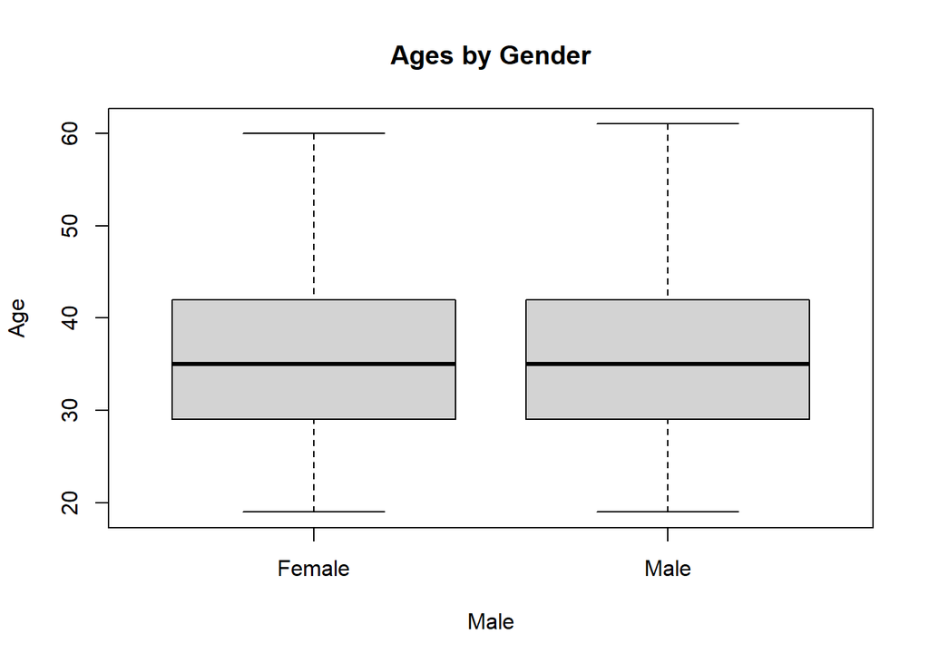

```r
boxplot(Age ~ Male,data = mydf,main = "Ages by Gender")
```

```r
#the distribution of ages does not vary with gender
```

```r
tapply(mydf$Age,mydf$Male,mean)
```

```
##   Female     Male
## 36.18690 35.81705
```

```r
# get the mean of ages grouped by gender..as we can see, mean does not vary with gender
```

**Get a side by side boxplot for ad clicks.**

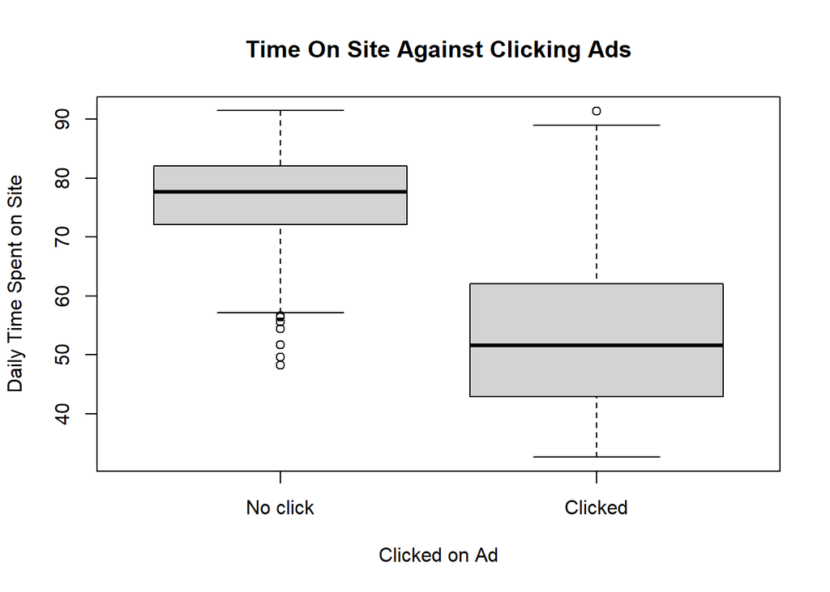

```r
boxplot(`Daily Time Spent on Site`~`Clicked on Ad`,data = mydf,main = "Time On Site Against Clicking Ads")
```

```r
# it seems that people who spend less time on the site are more likely to click on

# the ads
```

```r
# Identify difference in times of people who either clicked or did not click ADs

tapply(mydf$`Daily Time Spent on Site`,mydf$`Clicked on Ad`,mean)
```

```
## No click  Clicked
## 76.85462 53.14578
```

```r
# the average time of people who clicked on ADs is considerably less than

# those who did not click on ADs
```

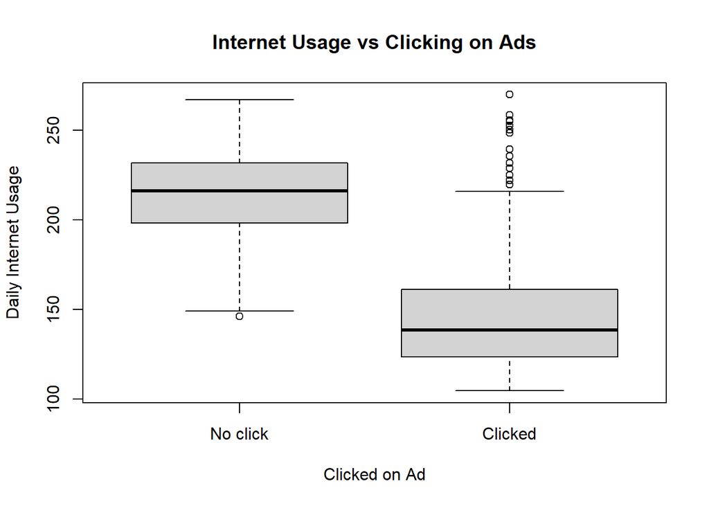

```r
boxplot(`Daily Internet Usage`~`Clicked on Ad`,data = mydf,main = "Internet Usage vs Clicking on Ads")
```

```r
# people with less daily internet usage were more likely to click an Ad
```

```r
tapply(mydf$`Daily Internet Usage`,mydf$`Clicked on Ad`,mean)
```

```
## No click  Clicked
## 214.5137 145.4865
```

**Distribution of age vs Income**

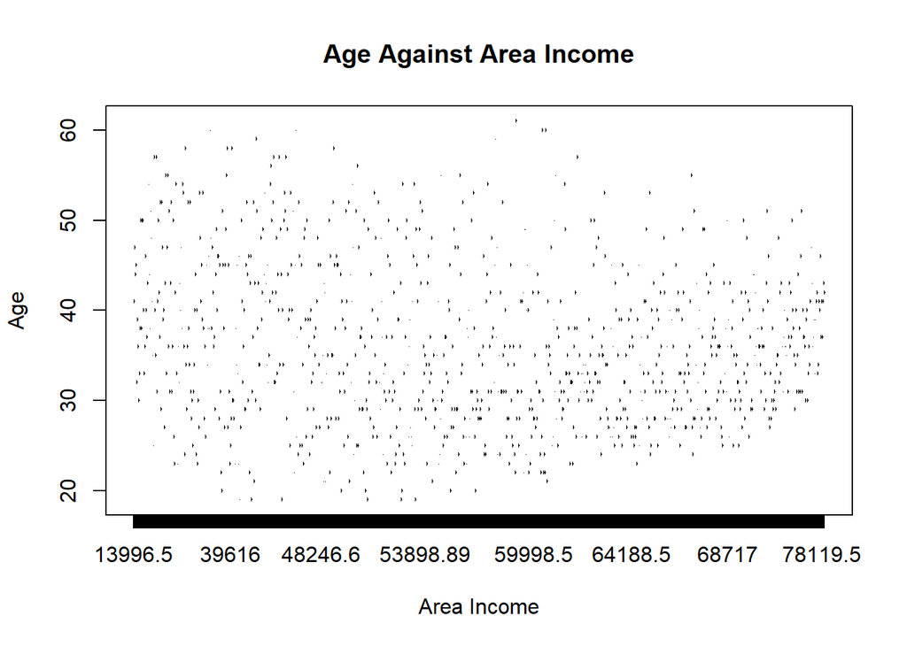

```r
boxplot(Age~`Area Income`,data = mydf,main = "Age Against Area Income")
```

**Find the correlation between age and are income.**

```r
cor(mydf$Age,mydf$`Area Income`)
```

```
## [1] -0.182605
```

```r
# weak negative correlation between age and income
```

**Distribution of time spend on site and daily internet usage.**

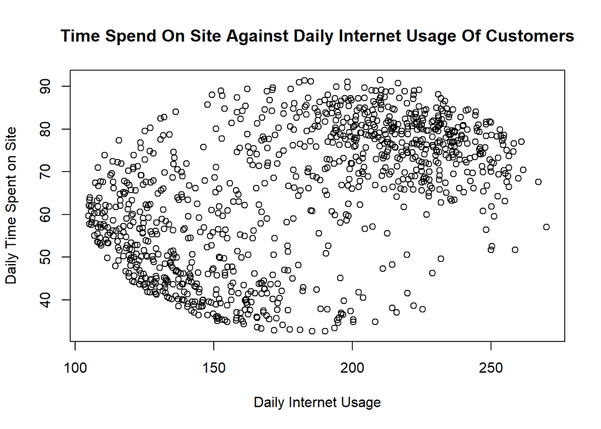

```r
plot(`Daily Time Spent on Site`~`Daily Internet Usage`,data = mydf,main = "Time Spend On Site Against Daily Internet Usage Of Customers")
```

Now find corrrelation between daily time spend on sight and internet usage

```r
cor(mydf$`Daily Time Spent on Site`,mydf$`Daily Internet Usage`)

# there is a relatively moderate correlation between time spend on site and internet usage
```

[output not shown]

**Now lets plot all scatter pairs for numeric variables.**

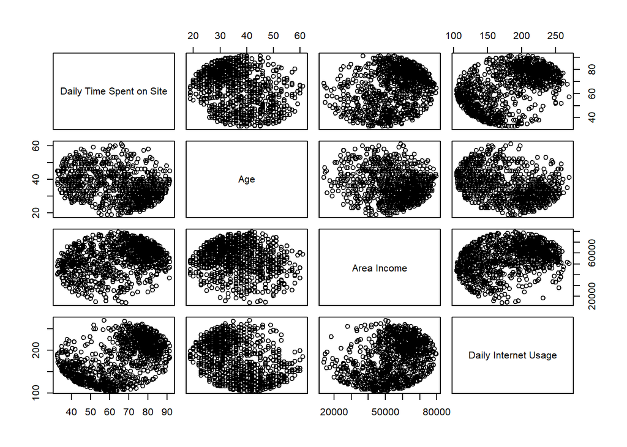

```r
mydf$Age <- as.numeric(mydf$Age)

pairs(mydf[,-c(5,6,7,8,9,10)])
```

```r
# now we have all scatter plot pairs from the data
```

```r
library(ggplot2)
```

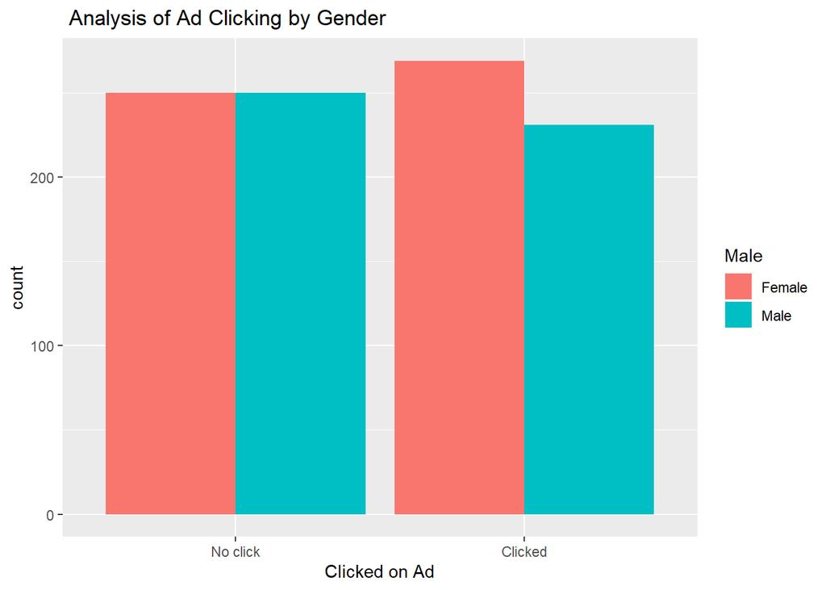

```r
ggplot(mydf,
       aes(x = `Clicked on Ad`,
           fill = Male))+
  geom_bar(position = "dodge")+
  labs(title = " Analysis of Ad Clicking by Gender")
```

## 1.9 .Multivariate analysis

**Get the corrrelation matrix from the data.**

```r
cor(mydf[,-c(5,6,7,8,9,10)])
```

```
##                          Daily Time Spent on Site        Age Area Income
## Daily Time Spent on Site                1.0000000 -0.3315133   0.3109544
## Age                                    -0.3315133  1.0000000  -0.1826050
## Area Income                             0.3109544 -0.1826050   1.0000000
## Daily Internet Usage                    0.5186585 -0.3672086   0.3374955
##                          Daily Internet Usage
## Daily Time Spent on Site            0.5186585
## Age                                -0.3672086
## Area Income                         0.3374955
## Daily Internet Usage                1.0000000
```

```r
# we can see that the area income and daily internet usage have a weak but positive

# linear relationship

# the daily time spend on site is also moderately correlated to the daily internet use
```

**Now lets get the multivariate aggregates of numerical variables.**

```r
aggregate(mydf$`Daily Time Spent on Site`~mydf$`Clicked on Ad`+mydf$Male,FUN = mean)
```

```
##   mydf$`Clicked on Ad` mydf$Male mydf$`Daily Time Spent on Site`
## 1             No click    Female                        77.00012
## 2              Clicked    Female                        54.40561
## 3             No click      Male                        76.70912
## 4              Clicked      Male                        51.67870
```

**Now lets get the number of people that clicked on ads given their gender only using a crosstab.**

```r
table(mydf$`Clicked on Ad`,mydf$Male)
```

```
##
##            Female Male
##   No click    250  250
##   Clicked     269  231
```

```r
#relatively more females clicked on ADs. But this could be due to the reason that there were more women sampled
```

```r
library(pch)
```

**Now lets investigate the relationship between clicking of ads and internet usage + time spend on site.**

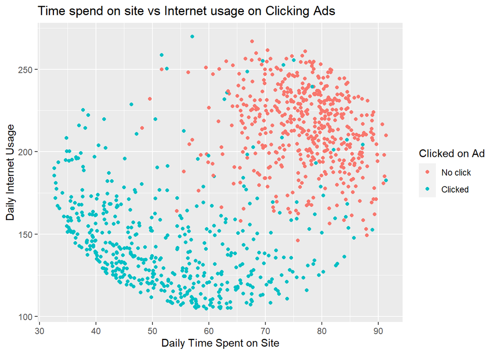

```r
ggplot(mydf,
       aes(x = `Daily Time Spent on Site`,
           y = `Daily Internet Usage`,
           color=`Clicked on Ad`))+
  geom_point()+labs(title = "Time spend on site vs Internet usage on Clicking Ads")
```

## 2.0. Recommendations.

**2.Since most of the customers visiting the site spend more time on the site than the** **average time spent, the Advertising team should consider pitching Ads that are** **relevant to the site or topic they are interested in.**

## 2.1. Challenging The Solution.

**The data acquired should probably have been more to do with the topics of the site** **visited rather than the clients visiting the site.**

**This would have given has more clarity on the type of interests the customers have.**